# Recipes

22 March, 2021

## Subaru Data Recipes

- `subaru_data.txt`: We discussed this data in class this week. This data set has 27K rows of Craigslist car listings. The response variable we’ll ultimately care about is `price`. There are a mix of helpful and unhelpful columns available to us.

Additionally, I have a task for you to perform that requires you to work with some time series information in R using `lubridate`.

```r
d.subaru <- read_tsv("subaru_data.txt") %>%
  mutate(odometer = as.numeric(odometer),
         year = as.numeric(year))

d.dates <- tibble(dt = seq(ymd("2018-01-01"),
                             ymd("2020-12-31"),
                             by="days")) %>%
  mutate(yr = year(dt),
         mon = month(dt,label=T),
         day = day(dt),
         week_day = wday(dt,label=T))
```

This section asks you to build a recipe for the Subaru data to process some of those columns. You’ll `prep` the recipe on `d.subaru`, then `juice` it to get the transformed tibble out. Then I’ve asked you to answer some questions about the results.

### Auto Models

The auto models in this data set are messy. There are 44 different makes and 74% of the values are missing. Here’s a messy picture:

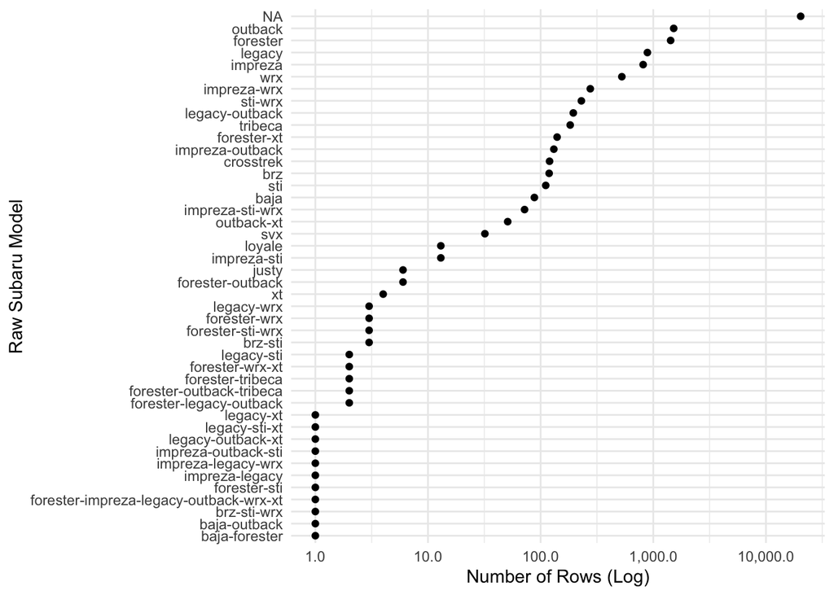

```r
 d.subaru %>%
  count(model) %>%
  mutate(model = fct_reorder(factor(model),.x=n,.fun=sum)) %>%
  ggplot(aes(x=n,y=model)) +
  geom_point() +
  theme_minimal() +
  labs(x="Number of Rows (Log)",y="Raw Subaru Model") +
  scale_x_log10(label=scales::comma_format())
```

The top five, (Outback, Forester, Legacy, Impreza, WRX) have enough data to support modeling. We’d like to map others to an “Other” category. When you build your recipe, include a step that transforms the `model` column to do this mapping.

### Odometer Data

The odometer data is hand-entered, which makes it messy. We could realistically expect a log-relationship with mileage, since going from 10K to 20K miles is different than going from 200K to 210K. Add a step to your recipe to do a log-transform of this column.

### Missing Data in Year

The `year` column clearly has some incorrect data in it. Additionally, the `year` column is completed for 84% of our rows. Using either the K-nearest neighbors or linear model imputation methods, add a recipe step that imputes `year`. Pay attention to what covariates you’re using to do the imputation and be prepared to justify your choices.

## Your Recipe

Use the code block below to add steps to your recipe.

```r
d.prep <- d.subaru %>%
  recipe() %>%
  # No steps yet, but yours go here.
  prep() %>%
  juice()
```

## Additional Tasks

With your `recipe` written, now some tasks for you:

1. Re-do the above plot of models on your prepped data. Interpret the results.
2. Build a plot of odometer reading in the original data versus the transformed data. Which observations look odd? Were any new infinite values created when you took the `log`? How come? What is a quick change to the recipe step that would eliminate these?
3. Make a scatterplot of counts by year in the original data versus in the imputed data. Which years show the biggest changes?

## Build Holiday Ranges

The list found at `timeDate::listHolidays()` may be useful for this exercise. Using a mix of `recipes` and `dplyr`, add the following columns to our `d.dates` data set:

- Add dummy variables for the major holidays in the US: Presidents’ Day, MLK’s Birthday, Christmas Day, Election Day, New Year’s Day, Thanksgiving, Veteran’s Day, Independence Day, Memorial Day, Labor Day, Christmas Eve, and New Year’s Eve.
- Add a column called `dt_spring` that has a 1 for every day between Easter Sunday and Labor Day. Note that this isn’t a canned `step_` function. (I had to do that for a model once because this was a busy time for shopping for spring clothing lines.)
- Have all your columns begin with the string “dt_” so that we can see them on the plot

To get you’ve started and to test the plotting, I’ve added one holiday for you.

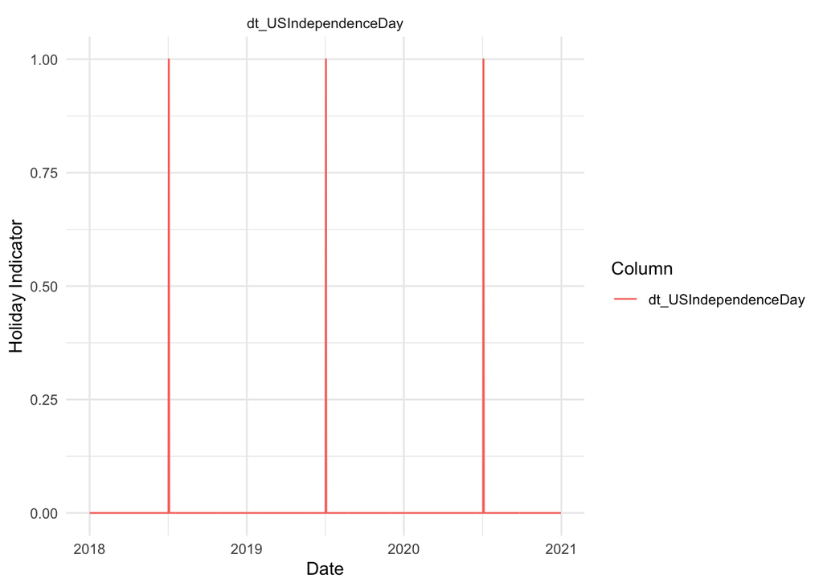

```r
prepped.date.data <- d.dates %>%
  recipe() %>%
  step_holiday(dt,holidays = c("USIndependenceDay")) %>%
  prep() %>%
  juice()


prepped.date.data %>%
  select(starts_with("dt")) %>%
  pivot_longer(cols=-dt,
               names_to="holiday") %>%
  ggplot(aes(x=dt,y=value,color=holiday)) +
  geom_line() +
  facet_wrap(~holiday) +
  theme_minimal() +
  labs(x="Date",y="Holiday Indicator",color="Column")
```